# EMBO Popgen 2026 – Genetic Drift & Selection

Daniel Wegmann

2026-06-15

### Transition probabilities under the Wright-Fisher model

**Q1)**. Let’s warm up by refreshing the Wright-Fisher model.

**a)** What is the average number of offspring per individual?

**Solutions**

Since the population size is constant, each individuals has on average 1 offspring.

**b)** What is the probability that an individual has no offspring at all? Does that depend on the population size?

**Solutions**

This is happening when each of the 2N individuals of the next generation picks another individual as its parent. Hence, $P(\mathrm{no\ offspring}) = \left(1-\frac{1}{2N}\right)^{2N}$, which does depend on the population size but becomes approximately 0.37 if $2N$ is large.

**Q2)** Consider a population of size $2N=100$ and a current allele frequency of $f=10/100 = 0.1$.

**a)** What is the probability that the allele frequency remains unchanged after one generation of random mating?

**Solutions**

Under the Wright-Fisher Model, transition probabilities are binomial. Hence, $P(n|2N, f)=\choose{2N}{n}f^n(1-f)^{2N})$. In R, we can get that probability using the function `dbinom()`:

```r
dbinom(x=10, size = 100, prob = 0.1)
```

[1] 0.1318653

**b)** What is the probability that the allele is lost after one generation of random mating?

**Solutions**

Again using `dbinom()`:

```r
dbinom(x=0, size = 100, prob = 0.1)
```

[1] 2.65614e-05

**c)** What is the probability that the allele is fixed after one generation of random mating?

**Solutions**

Again using `dbinom()`:

```r
dbinom(x=100, size = 100, prob = 0.1)
```

```
## [1] 1e-100
```

**d)** What is the probability that the allele frequency decreases after one generation of random mating?

**Solutions**

To calculate the probability of a decrease, we need to integrate the transition probability from 0 to n-1. In R, we can use the function `pbinom()`:

```r
pbinom(9, size = 100, prob = 0.1)
```

```
## [1] 0.4512902
```

**d)** What is the probability that the allele frequency increases after one generation of random mating?

**Solutions**

```r
1 - pbinom(10, size = 100, prob = 0.1)
```

```
## [1] 0.4168445
```

Note that the probabilities for an increase and decrease are not equal, i.e. this distribution is not symmetric.

**Q3)** Plot the probability distribution on the allele frequency for a current allele frequency $f= 0.1$ and $2N=10$, $2N=100$, $2N=1000$ and $2N=10000$. What is the effect of population size?

**Solutions**

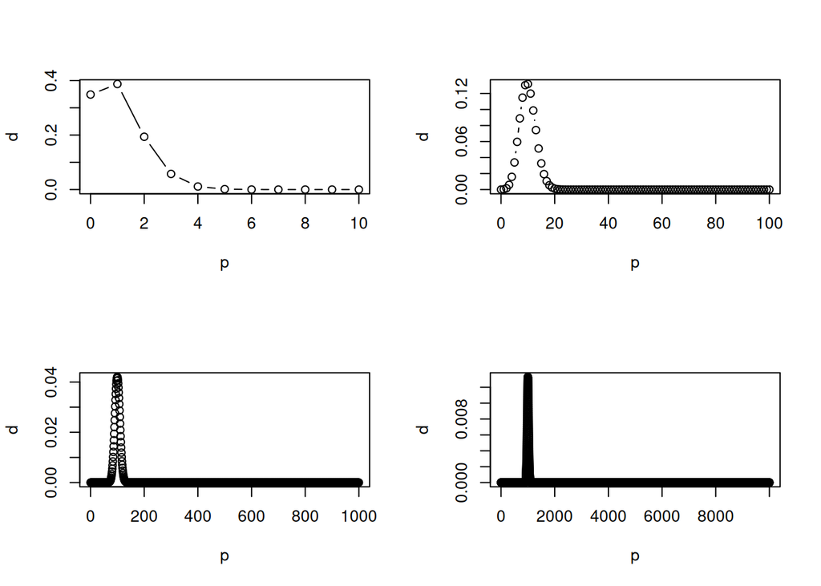

```r
par(mfrow=c(2,2))
for(twoN in c(10, 100, 1000, 10000)){
  p <- 0:twoN
  d <- dbinom(p, size = twoN, prob = 0.1)
  plot(p, d, type = 'b')
}
```

### Simulating neutral allele frequency trajectories

**Q4)** Write a function `simulateWF()` to simulate allele trajectories under the Wright-Fisher model. Your function should take as input i) the population size $2N$, ii) the initial allele frequency $f$ and iii) the number $G$ of generations to simulate. It should then return the allele frequency (between 0 and 1) for each generation as a vector.

**Solutions**

We can use the function `rbinom()` to simulate trajectories:

```r
simulateWF <- function(twoN, f, G){
  p <- numeric(G + 1)
  p[1] <- f
  for(i in 1:G){
    p[i+1] <- rbinom(1, size = twoN, prob = p[i]) / twoN
  }
  return(p)
}
```

**Q5)** Use your function `simulateWF()` to simulate 1000 trajectories with $2N=100$ and $f=0.1$ for $G=1000$ and plot them in one plot. In how many cases was the allele lost? Does this match the expectation? Repeat for different population sizes and initial allele frequencies. What is the effect of the population size?

**Solutions**

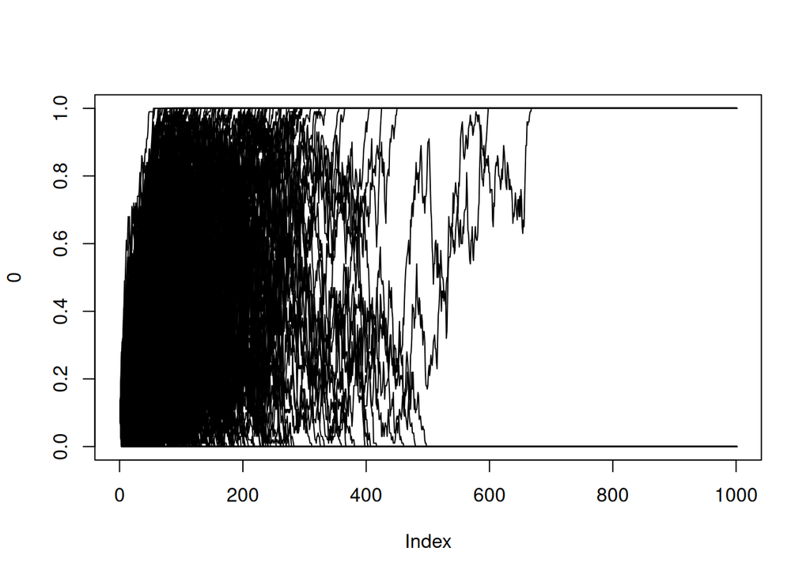

```r
trajectories <- replicate(1000, simulateWF(twoN = 100, f = 0.1, G = 1000))
plot(0, type='n', ylim=c(0,1), xlim=c(0, nrow(trajectories)))
invisible(apply(trajectories, 2, lines, type='l'))
```

```r
print(paste("Allele was lost in", sum(trajectories[1000,] == 0), "/", ncol(trajectories), "cases."))
```

```
## [1] "Allele was lost in 893 / 1000 cases."
```

The allele is expected to go to fixation with the probability of its initial allele frequency $f$, and hence to be lost with probability $1-f$.

If you use larger population sizes, you should observe less fluctuation and eventually many sites will remain polymorphic even after $G=1000$ generations. However, if run for enough generations, the same fraction of alleles will be lost.

**Q6)** Use your function `simulateWF()` to study fixation probability of a new mutation under different population sizes (ensure $G$ is large enough). Does the fixation probability depend on the population size? How does this affect the substitution rate?

**Solutions**

To study the fixation probability of a new mutation, set $f=\frac{1}{2N}$.

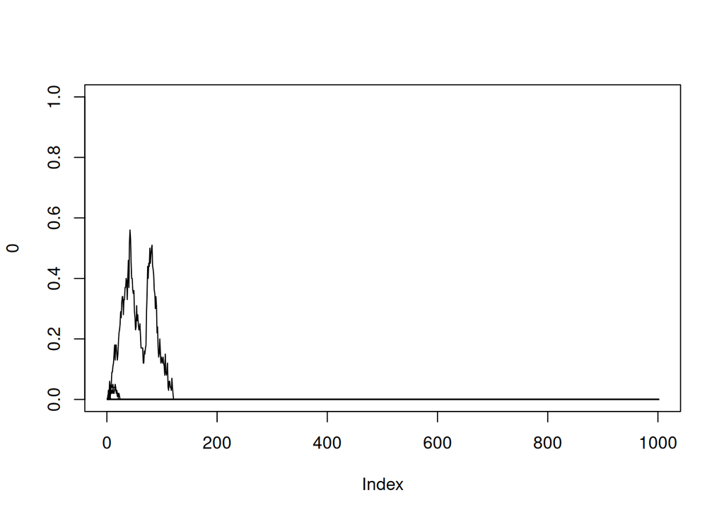

```r
trajectories <- replicate(1000, simulateWF(twoN = 100, f = 1/twoN, G = 1000))
plot(0, type='n', ylim=c(0,1), xlim=c(0, nrow(trajectories)))
invisible(apply(trajectories, 2, lines, type='l'))
```

```r
print(paste("Allele was fixed in", sum(trajectories[1000,] == 1), "/", ncol(trajectories), "cases."))
```

```
## [1] "Allele was fixed in 0 / 1000 cases."
```

The fixation probability of any mutation is given by its current frequency $f$ and is hence markedly different between small and large populations. The substitution rate, hower, is not since there are $2N\mu$ mutations occuring per generation, and hence many more in large than small populations.

### Simulating selection and genetic drift

**Q7)** Write a function `simulateWFWithSelection()` that simulates allele trajectories under both genetic drift and viability selection. Similar to your function `simulateWF()` you wrote above, it should take as input i) the population size $2N$, ii) the initial allele frequency $f$, iii) the number $G$ of generations to simulate and iv) also a vector $v$ of viabilities for the genotypes AA, Aa and aa. It should then return the allele frequency (between 0 and 1) for each generation as a vector. In each generation, your function should apply selection to alter the allele frequency, and then use binomial sampling to simulate genetic drift in that modified allele frequency.

**Solutions**

We can use the function `rbinom()` to simulate trajectories:

```r
simulateWFWithSelection <- function(twoN, f, G, v){
  p <- numeric(G + 1)
  p[1] <- f
  for(i in 1:G){
    # selection
    fA <- p[i]
    fa <- 1-fA
    fPrime <- (v[1]*fA*fA + v[2]*fA*fa)/(v[1]*fA*fA + v[2]*2*fA*fa + v[3]*fa*fa);
    # drift
    p[i+1] <- rbinom(1, size = twoN, prob = fPrime) / twoN
  }
  return(p)
}
```

**Q8)** Use your function `simulateWFWithSelection()` to simulate 1000 trajectories with $2N=100$, and $f=0.1$ and genic selection with viabilities $v=(1, 1-s, (1-s)^2)$ for $G=1000$ and plot them in one plot. Start with $s=0.01$. How strong does the selection coefficient $s$ have to be to see differences to the neutral case simulated above (or simulated with `simulateWFWithSelection()` when setting $v=(1,1,1)$)? How is this affected by the population size $2N$?

**Solutions**

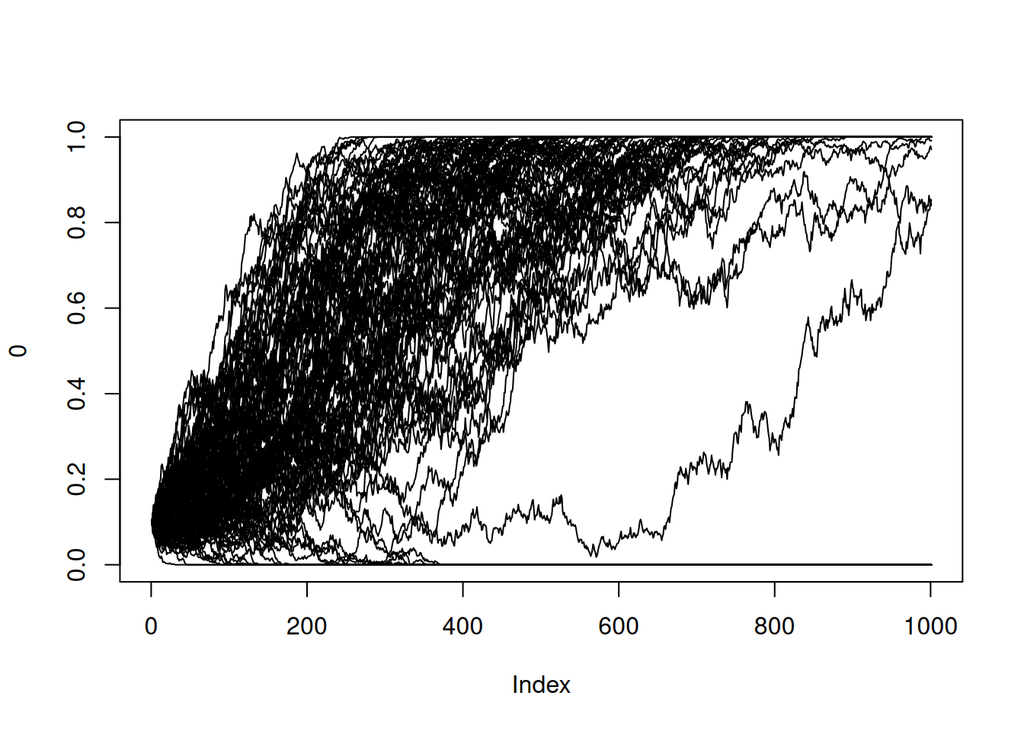

```r
s <- 0.01
trajectories <- replicate(100, simulateWFWithSelection(twoN = 1000, f = 0.1, G = 1000, v=c(1,1-s,(1-s)^2)))
plot(0, type='n', ylim=c(0,1), xlim=c(0, nrow(trajectories)))
invisible(apply(trajectories, 2, lines, type='l'))
```

```r
print(paste("Allele was fixed in", sum(trajectories[1000,] == 1), "/", ncol(trajectories), "cases."))
```

```
## [1] "Allele was fixed in 82 / 100 cases."
```

**Q9)** Set $2N=10^6$ and dominant $v=(1, 1, 1-s)$ with $s=0.05$. How often does the allele go to fixation within $G=1000$? And in case of a smaller population size? How does it look like for the recessive case?

**Solutions**

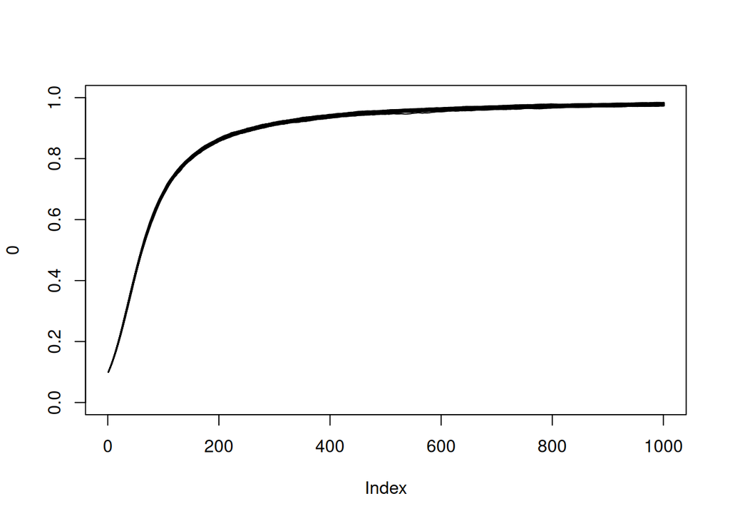

```r
s <- 0.05
trajectories <- replicate(100, simulateWFWithSelection(twoN = 10^6, f = 0.1, G = 1000, v=c(1,1,1-s)))
plot(0, type='n', ylim=c(0,1), xlim=c(0, nrow(trajectories)))
invisible(apply(trajectories, 2, lines, type='l'))
```

```r
print(paste("Allele was fixed in", sum(trajectories[1000,] == 1), "/", ncol(trajectories), "cases."))
```

```
## [1] "Allele was fixed in 0 / 100 cases."
```

Despite a large population $2N=10^6$ and strong selection $s=0.05$, the allele is essentially never fixed. This is because there is no selection benefiting the heterozygous Aa over the homozygous AA genotype and drift is too weak to push the allele to fixation. When using a smaller population size such as $2N=10^3$ the allele is essentially always fixed because selection is strong enough to push it quickly to high frequencies, and drift strong enough to fix it by random fluctuations.

In the recessive case $v=c(1, 1-s, 1-s)$ with $s=0.05$ and $2N=10^6$, the allele is always fixed. When using a smaller population size (e.g. $2N=1^3$), the allele is occasionally lost early on because of drift (random fluctuations) before selection could push the allele to a high enough frequency, also because there is no selection benefiting the heterozygous Aa over the homozygous aa genotype.